# Part of Speech Tagging Assignment

Yueze Xu

2021-06-15

## Libraries / R Setup

- In this section, include the libraries you need for the *R* questions.

```r
##r chunk
#devtools::install_github("bradleyboehmke/harrypotter")
#setwd("C:/Users/hera-/Desktop/HU/ANLY520")
library(harrypotter)
library(reticulate)
py_config()
```

```
## python:         C:/Program Files/Python38/python.exe
## libpython:      C:/Program Files/Python38/python38.dll
## pythonhome:     C:/Program Files/Python38
## version:        3.8.2 (tags/v3.8.2:7b3ab59, Feb 25 2020, 23:03:10) [MSC v.1916 64 bit (AMD64)]
## Architecture:   64bit
## numpy:          C:/Users/hera-/AppData/Roaming/Python/Python38/site-packages/numpy
## numpy_version:  1.20.3
##
## NOTE: Python version was forced by RETICULATE_PYTHON
```

```r
library(tagger)
library(dplyr)
library(rJava)
library(RDRPOSTagger)
##pick one of the harrypotter books to analyze with your POS text
##https://github.com/bradleyboehmke/harrypotter check out the options
##load it using data(book title)
data(half_blood_prince)
content = half_blood_prince[1]

py_module_available("spacy")
```

```
## [1] TRUE
```

```r
py_module_available("nltk")
```

```
## [1] TRUE
```

- In this section, include import functions to load the packages you will use for Python.
- Also transfer your `book_data` from R into Python.

```python
##python chunk
import spacy
import nltk
import pandas as pd
from nltk.corpus import brown
book_data = r.content
```

## Tagger Package

- Use the `tagger` package to tag your chosen book and print out the first chapter only (i.e., row 1 of the book you chose).
- Use something like `(book[1])[[1]][1:10]` to print out the first few tags.
- Use the universal tag set and plot options to see what the most common parts of speech are for your chapter.
- What are the top two most common parts of speech?  
  **The top two most common parts are “NOUN” and “VERB”**

```r
##r chunk
sentence = py$book_data
tag_pos = tag_pos(sentence)
print(tag_pos[[1]][1:10])#first few tags
```

```
##        PRP        VBD        VBG         NN         CC         DT        NNP
##       "It"      "was"  "nearing" "midnight"      "and"      "the"    "Prime"
##        NNP        VBD        VBG
## "Minister"      "was"  "sitting"
```

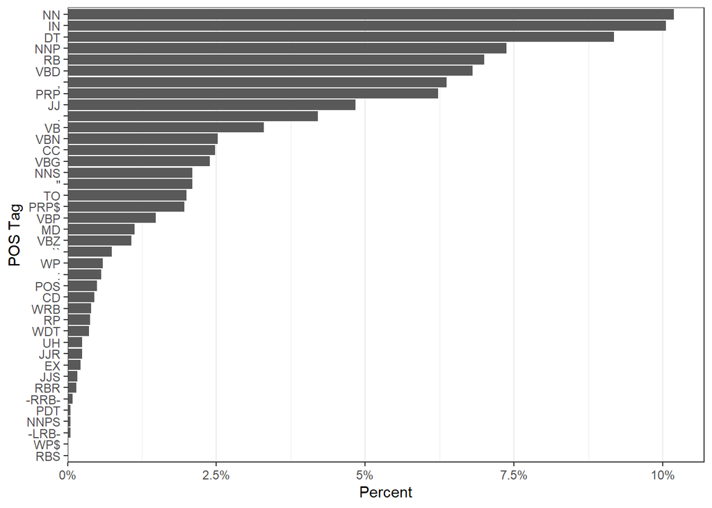

```r
tag_pos(sentence) %>% plot()
```

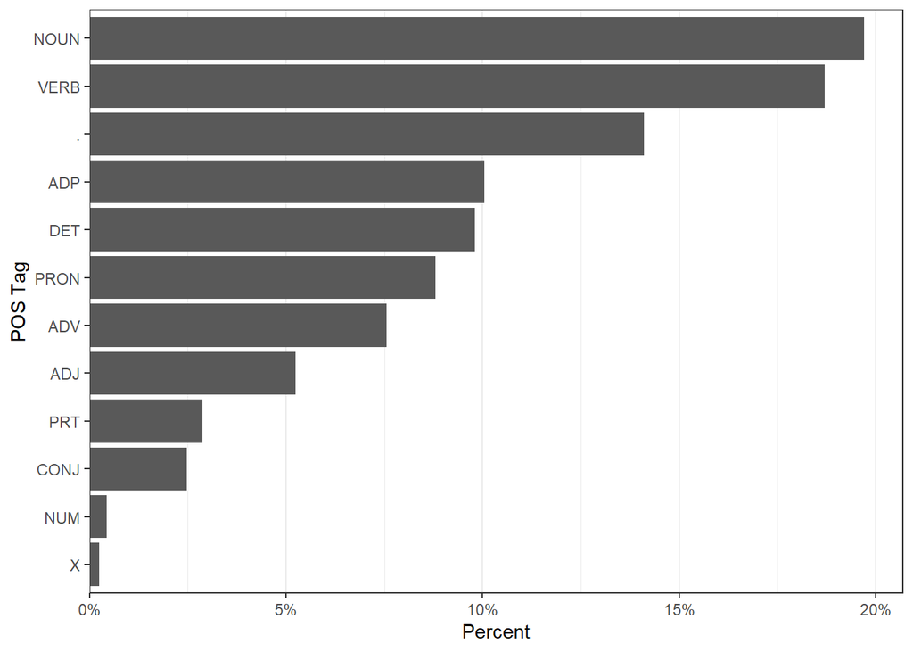

```r
tag_pos(sentence) %>% as_universal() %>% plot()
```

## RDR POS Tagger

- Create an English language model that tags for part of speech.
- Tag your first book chapter for part of speech.
- Use something like `head(...(book[1]))` to print out the first few examples.

```r
##r chunk
create_tagger <- rdr_model(language = "English", annotation = "POS")
first_chap <- rdr_pos(create_tagger, x = sentence)
head(first_chap)
```

```
##   doc_id token_id    token pos
## 1     d1        1       It PRP
## 2     d1        2      was VBD
## 3     d1        3  nearing VBG
## 4     d1        4 midnight  NN
## 5     d1        5      and  CC
## 6     d1        6      the  DT
```

## spaCy

- Import spacy and the English language module.
- Tag the first chapter of your book using spacy, and print out the results.
- Use the `pandas` option at the beginning of the lecture to print out only a few rows.

```python
##python chunk
nlp = spacy.load('en_core_web_sm')
tagged_sentence = nlp(book_data)
py_pos_tagged = [(word.text, word.pos_, word.tag_) for word in tagged_sentence]
#py_pos_tagged
pd.DataFrame(py_pos_tagged).T
```

```
##     0     1    2        3         4     ...   6229  6230   6231      6232   6233
## 0           It  was  nearing  midnight  ...  green  fire    and  vanished      .
## 1  SPACE  PRON  AUX     VERB      NOUN  ...    ADJ  NOUN  CCONJ      VERB  PUNCT
## 2    _SP   PRP  VBD      VBG        NN  ...     JJ    NN     CC       VBD      .
##
## [3 rows x 6234 columns]
```

## Training your own tagger

- Create a Default tagger in Python using `nltk`.
- The default option should be “NN” for nouns.
- You do not have to use the tagger yet, just create it for a combined tagger to use later. (Don’t tag! Don’t print it out!)

```python
##python chunk
default_tagger = nltk.DefaultTagger('NN')

#just randomly picking the words
#news   Chicago Tribune: Society Reportage
#reviews    Time Magazine: Reviews
#tokens = brown.words(categories =["news", "reviews"])
#tag those words!
#pd.DataFrame(default_tagger.tag(tokens)).head
#how good of the tagging
#brown_tagged_sents = brown.tagged_sents()
#default_tagger.evaluate(brown_tagged_sents)
#0.13130472824476916
```

## Unigram Tagger

- Create a unigram tagger that is trained on the entire Brown corpus with tagged sentences.
  - Import the Brown corpus.
  - Split the data into test and train.
  - Train your unigram tagger on the training sentences.
  - Use the default tagger you created above as the backoff.
  - Do not use the tagger here, just train it.

```python
##python chunk
from nltk.corpus import brown

brown_tagged_sents = brown.tagged_sents()
#separate the data into train and test
size = int(len(brown_tagged_sents) * 0.7)
train_ = brown_tagged_sents[:size]
test_ = brown_tagged_sents[size:]

##create a function (training) on the first part
unigram_tagger = nltk.UnigramTagger(train_)

#combining taggers
#single words in context, go back to noun if necessary
t1 = nltk.UnigramTagger(train_, backoff=default_tagger)
##double words in context, back up to single words
t2 = nltk.BigramTagger(train_, backoff=t1)
```

## Evaluate

- Use the `.evaluate` function on your testing data to determine the accuracy of your tagger.

```python
##python chunk
##test on the second part:
unigram_tagger.evaluate(test_)
#test on the first part:
```

```
## 0.8725226707282359
```

```python
t1.evaluate(test_)
#test on the combined
```

```
## 0.8801048417207942
```

```python
t2.evaluate(test_)
```

```
## 0.9015315911468634
```

## Apply to Harry Potter

- Use the tagger you created above to apply to the first chapter of your Harry Potter book.
- Hint: save your book as only the first chapter and then transfer to python to help make this shorter.
- Second hint: be sure to tokenize the data first!
- Use something like `tagger.tag(book)[1:10]` to print out only the first ten tags.

```python
##python chunk
tokens = nltk.word_tokenize(book_data)
print(unigram_tagger.tag(tokens)[1:10])
```

```
## [('was', 'BEDZ'), ('nearing', 'VBG'), ('midnight', 'NN'), ('and', 'CC'), ('the', 'AT'), ('Prime', 'JJ-TL'), ('Minister', 'NN-TL'), ('was', 'BEDZ'), ('sitting', 'VBG')]
```

```python
print(t1.tag(tokens)[1:10])
```

```
## [('was', 'BEDZ'), ('nearing', 'VBG'), ('midnight', 'NN'), ('and', 'CC'), ('the', 'AT'), ('Prime', 'JJ-TL'), ('Minister', 'NN-TL'), ('was', 'BEDZ'), ('sitting', 'VBG')]
```

```python
print(t2.tag(tokens)[1:10])
```

```
## [('was', 'BEDZ'), ('nearing', 'VBG'), ('midnight', 'NN'), ('and', 'CC'), ('the', 'AT'), ('Prime', 'JJ-TL'), ('Minister', 'NN-TL'), ('was', 'BEDZ'), ('sitting', 'VBG')]
```